# Practice 7.4 - LV

R13B42015

2024-11-17

```r
library(dplyr)
library(tidyr)
library(ggplot2)
```

# Define the correlation function

```r
cor_func<- function(dataset, day_start, day_end, treatment)
{
  #############################
  # set vector of test data
  treatment_start<- dataset[dataset$treatment == treatment, day_start]
  treatment_end<- dataset[dataset$treatment == treatment, day_end]

  #############################
  # correlation (r value)
  r<- cor(treatment_start, treatment_end)
  #############################
  # t value
  n <- length(treatment_start)  # 假設樣本數
  t_value <- r * sqrt(n - 2) / sqrt(1 - r^2)
  #############################
  # p value
  degree_of_freedom<- n - 2
  p_value <- 2 * (1 - pt(abs(t_value), df = degree_of_freedom))
  print(p_value)

  cat("data: gress length of ", day_start," and ",day_end, "\n",
      "treatment: ", treatment, "\n",
      "t = ", t_value, "\n",
      "p value = ", p_value, "\n",
      "correlation: ", r)

  return(data.frame(day_start = day_start, day_end = day_end,
                    treatment = treatment, correlation = r,
                    t = t_value, p_value = p_value))
}
```

# read dataset

```r
rairuoho <- read.table("C:\\ocean5098\\02.3-Rairuoho\\rairuoho_data.txt", header = TRUE)
head(rairuoho,5)
```

```
##   day3 day4 day5 day6 day7 day8 germinate    bed treatment spatial1 spatial2
## 1    2   13   34   85  112  121        18 paper4  nutrient    upper     left
## 2    5   22   60   95  108  116        19 mould1  nutrient    upper     left
## 3    5   26   34   73   96  111        18 paper8  nutrient    upper     left
## 4    7   24   61   91  101  117        17 mould2  nutrient    upper     left
## 5    0    9   31   61   92  116        12 paper4  nutrient    lower     left
##   row column
## 1   1      1
## 2   2      1
## 3   3      1
## 4   4      1
## 5   5      1
```

# Create Boxplots for Grass Length Comparison

[figure not shown]

```r
rairuoho_long <- pivot_longer(rairuoho, cols = c(day3, day4), names_to = "day", values_to = "length")
ggplot(rairuoho_long, aes(x = day, y = length, fill = treatment)) +
  geom_boxplot() +
  labs(title = "Comparison of grass length on day 3 and day 8 between different treatments",
       x = "day",
       y = "length")
```

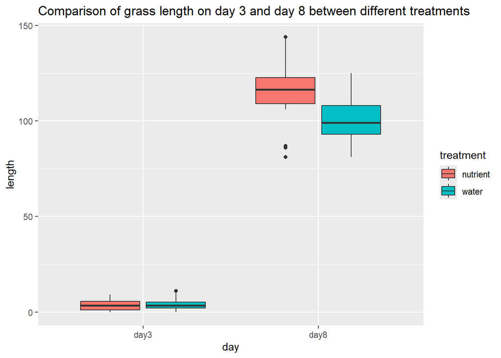

```r
rairuoho_long <- pivot_longer(rairuoho, cols = c(day3, day8), names_to = "day", values_to = "length")
ggplot(rairuoho_long, aes(x = day, y = length, fill = treatment)) +
  geom_boxplot() +
  labs(title = "Comparison of grass length on day 3 and day 8 between different treatments",
       x = "day",
       y = "length")
```

# Perform Correlation Tests

```r
treatments <- c("water", "nutrient")
day_pairs <- list(c("day3", "day4"), c("day3", "day8"))
results <- data.frame()
for(treatment in treatments)
{
  for(day_pair in day_pairs)
  {
    result<- cor_func(rairuoho, day_pair[1], day_pair[2], treatment)
    results <- rbind(results, result)
  }
}
```

```
## [1] 5.197822e-06
## data: gress length of  day3  and  day4
##  treatment:  water
##  t =  5.972364
##  p value =  5.197822e-06
##  correlation:  0.7864562[1] 0.02386844
## data: gress length of  day3  and  day8
##  treatment:  water
##  t =  2.426958
##  p value =  0.02386844
##  correlation:  0.4595545[1] 8.93837e-06
## data: gress length of  day3  and  day4
##  treatment:  nutrient
##  t =  5.741382
##  p value =  8.93837e-06
##  correlation:  0.774425[1] 0.2552119
## data: gress length of  day3  and  day8
##  treatment:  nutrient
##  t =  1.168247
##  p value =  0.2552119
##  correlation:  0.2416871
```

```r
results
```

```
##   day_start day_end treatment correlation        t      p_value
## 1      day3    day4     water   0.7864562 5.972364 5.197822e-06
## 2      day3    day8     water   0.4595545 2.426958 2.386844e-02
## 3      day3    day4  nutrient   0.7744250 5.741382 8.938370e-06
## 4      day3    day8  nutrient   0.2416871 1.168247 2.552119e-01
```

# Results:

1. Water Treatment  
   **Correlation between Day 3 and Day 4**  
   Correlation coefficient ( r = 0.7865 ): This indicates a strong positive correlation between the lengths on Day 3 and Day 4. p value = 5.197822e-06, this value is less than 0.01, showing that this correlation is statistically very significant.  
   **Correlation between Day 3 and Day 8**  
   Correlation coefficient ( r = 0.4596 ): This shows a moderate positive correlation between lengths on Day 3 and Day 8. p value = 2.386844e-02, this value is less than 0.05, indicating that this correlation is also significant, but the significance is weaker compared to the first pair of comparisons.
2. Nutrient Treatment  
   **Correlation between Day 3 and Day 4**  
   Correlation coefficient ( r = 0.7744 ): This shows a strong positive correlation, similar to the water treatment group. p value = 8.938370e-06, this value also shows high significance.  
   **Correlation between Day 3 and Day 8**  
    Correlation coefficient ( r = 0.2417 ): This value indicates a weak positive correlation.p value = 2.552119e-01, this value is greater than 0.05, suggesting that this correlation is not statistically significant.

# Conclusion

From the above analysis, we observe that:

• The Water Treatment shows a strong and significant correlation between Day 3 and Day 4, while a moderate and significant correlation exists between Day 3 and Day 8.  
• The Nutrient Treatment also demonstrates a strong and significant correlation between Day 3 and Day 4, but the correlation between Day 3 and Day 8 lacks significance.

These results may imply that treatments using water and nutrients have a noticeable impact on the early growth (i.e., the relationship between lengths on Day 3 and Day 4), while the growth length on Day 8 seems less affected by the length on Day 3.